# Analyse der Flugdaten der Schweizer Armeedrohnen Ranger

Vorprozessierung und Analyse

Angelo Zehr und Julian Schmidli

Juli 2017

## Vorbemerkungen

Dieses Dokument beschreibt die Vorprozessierung und explorative Analyse des Datensatzes, der Grundlage des auf srf.ch veröffentlichten Artikel [Grenzwächter der Lüfte](http://www.srf.ch/news/grenzwaechter-der-luefte-2/) ist.

SRF Data legt Wert darauf, dass die Datenvorprozessierung und -Analyse nachvollzogen und überprüft werden kann. SRF Data glaubt an das Prinzip offener Daten, aber auch offener und nachvollziehbarer Methoden. Zum anderen soll es Dritten ermöglicht werden, auf dieser Vorarbeit aufzubauen und damit weitere Auswertungen oder Applikationen zu generieren.

Die Vorprozessierung und Analyse wurde im Statistikprogramm R vorgenommen.

Die Endprodukte des vorliegenden Scripts, neben der vorliegenden explorativen Analyse, sind (Datenbeschreibung siehe unten):

- `flights.csv`: Die Flugdaten mit Timestamp, Geolocation, Flugzeugname und eindeutiger Flug-ID.
- `hours.csv`, `weekdays.csv`, `days.csv`: Anzahl Flüge nach Uhrzeit, Wochentag und Datum. (z.T. unterteilt in Grenz- und Nicht-Grenzflüge)

### R-Script & Daten

Die Vorprozessierung und Analyse wurde im Statistikprogramm R vorgenommen. Das zugrunde liegende Script sowie die prozessierten Daten können unter [diesem Link](https://srfdata.github.io/2017-07-drohnen/rscript.zip) heruntergeladen werden. Durch Ausführen von `main.Rmd` kann der hier beschriebene Prozess nachvollzogen und der für den Artikel verwendete Datensatz generiert werden. Dabei werden Daten aus dem Ordner `input` eingelesen und Ergebnisse in den Ordner `output` geschrieben.

SRF Data verwendet das rddj-template von Timo Grossenbacher als Grundlage für seine R-Scripts. Entstehen bei der Ausführung dieses Scripts Probleme, kann es helfen, die Anleitung von rddj-template zu studieren.

Debug-Informationen: *This report was generated on 2018-12-07 13:33:09. R version: 3.4.4 on x86_64-pc-linux-gnu. For this report, CRAN packages as of 2017-06-01 were used.*

### GitHub

Der Code für die vorliegende Datenprozessierung ist auf https://github.com/srfdata/2017-07-drohnen zur freien Verwendung verfügbar.

### Lizenz

2017-07-drohnen von [SRF Data](https://github.com/srfdata/2017-07-drohnen) ist lizenziert unter einer [Creative Commons Namensnennung - Weitergabe unter gleichen Bedingungen 4.0 International Lizenz](http://creativecommons.org/licenses/by-sa/4.0/).

### Weitere Projekte

Code & Daten von [SRF Data](http://srf.ch/data) sind unter http://srfdata.github.io verfügbar.

### Haftungsausschluss

Die veröffentlichten Informationen sind sorgfältig zusammengestellt, erheben aber keinen Anspruch auf Aktualität, Vollständigkeit oder Richtigkeit. Es wird keine Haftung übernommen für Schäden, die durch die Verwendung dieses Scripts oder der daraus gezogenen Informationen entstehen. Dies gilt ebenfalls für Inhalte Dritter, die über dieses Angebot zugänglich sind.

### Datenbeschreibung

#### flights.csv

Die Flugdaten, unterteilt in 4 Gruppen: - `allFlights` beinhaltet alle relevanten Flugmesspunkte. - `borderFlights` beinhaltet die Flugmesspunkte jener Flüge, die an irgendeiner Stelle **näher als 5km an der Schweizer Grenze** sind. - `domesticFlights` beinhaltet die Flugmesspunkte jener Flüge, die an **keiner** Stelle näher als 5km an der Schweizer Grenze sind. - `irrelevantFlights` beinhaltet die irrelevanten Flüge, die weniger als 15 Minuten waren oder weniger als 40 Messpunkte enthalten.

| Attribut | Typ | Beschreibung |
| --- | --- | --- |
| Timestamp | Numeric | Unix-Timestamp des einzelnen Flugmesspunktes. |
| altitude | Numeric | Altitude (Fuss über Meeresspiegel) des einzelnen Flugmesspunktes. |
| heading | Numeric | Flugrichtung des einzelnen Flugmesspunktes. |
| lat | Numeric | Geografische Breite des einzelnen Flugmesspunktes. |
| long | Numeric | Geografische Länge des einzelnen Flugmesspunktes. |
| radar_id | Numeric | Id der Messstation, die das Signal empfangen hat. |
| squawk | Numeric | Broadcast-Code des Flugobjekts. |
| File | String | Datei, in der der Flug abgespeichert war. |
| flight | Numeric | Eindeutige ID eines Fluges. |
| drone | String | Name des Flugobjekts. |
| date | Datum | Datum und Uhrzeit des einzelnen Flugmesspunktes. |
| distance | Numeric | Distanz des einzelnen Flugmesspunktes zum zuletzt gemessenen. |
| seconds | Numeric | Anzahl Sekunden seit der letzten Messung. |
| speed | Numeric | Distanz in Kilometer pro Stunde, berechnet aus distance und seconds. |
| borderRegion | Bool | True/False: Befindet sich der Flugpunkt näher als 5 Kilometer an der Schweizer Grenze? |
| borderFlight | Bool | True/False: Befindet sich irgend ein Flugpunkt dieses Fluges näher als 5 Kilometer an der Schweizer Grenze? |

#### hours.csv

| Attribut | Typ | Beschreibung |
| --- | --- | --- |
| hour | String | Stunde des Tages (00-23) als Text mit vorangestellten Nullen. |
| borderFlight | Bool | True/False: Befindet sich irgend ein Flugpunkt dieses Fluges näher als 5 Kilometer an der Schweizer Grenze? |
| n | Numeric | Anzahl der Flüge zu dieser Stunde und in dieser Kategorie (Grenzflug oder nicht Grenzflug). |

#### weekdays.csv

| Attribut | Typ | Beschreibung |
| --- | --- | --- |
| weekday | Numeric | Wochentag als Zahl (Montag 1 bis Sonntag 7). |
| borderFlight | Bool | True/False: Befindet sich irgend ein Flugpunkt dieses Fluges näher als 5 Kilometer an der Schweizer Grenze? |
| n | Numeric | Anzahl der Flüge an diesem Wochentag und in dieser Kategorie (Grenzflug oder nicht Grenzflug). |

#### days.csv

| Attribut | Typ | Beschreibung |
| --- | --- | --- |
| date | Date | Datum |
| n | Numeric | Anzahl der Flüge an diesem Tag (sowohl Grenz- als auch Nicht-Grenzflüge). |

### Originalquelle

Originalquelle der Flugdaten ist [Flightradar24.com](http://flightradar24.com). Die Daten zur Schweizer Landesgrenze wurden vom [Bundesamt für Statistik](https://www.bfs.admin.ch/bfs/de/home/dienstleistungen/geostat/geodaten-bundesstatistik/administrative-grenzen.html) bezogen, ein Höhenprofil der Schweiz von [CGIAR-CSI](http://srtm.csi.cgiar.org/SELECTION/inputCoord.asp) und eine Liste von Schweizer Städten von [rueegger.me](https://rueegger.me/2008/06/15/schweizer-postleitzahlen-mit-koordinaten.html).

## Vorbereitungen

```
## [1] "package package:rmarkdown detached"
```

### Packages definieren

```r
# von https://mran.revolutionanalytics.com/web/packages/checkpoint/vignettes/using-checkpoint-with-knitr.html
cat("
library(devtools)
library(ggplot2)
library(ggrepel)
library(knitr)
library(magrittr)
library(RColorBrewer)
library(raster)
library(readr)
library(rgeos)
library(sp)
library(rgdal)
library(tidyr)
library(dplyr)
",
file = "manifest.R")
```

### Packages installieren

```r
# if checkpoint is not yet installed, install it (for people using this
# system for the first time)
if (!require(checkpoint)) {
  if (!require(devtools)) {
    install.packages("devtools", repos = "http://cran.us.r-project.org")
    require(devtools)
  }
  devtools::install_github("RevolutionAnalytics/checkpoint",
                           ref = "v0.3.2", # could be adapted later,
                           # as of now (beginning of July 2017
                           # this is the current release on CRAN)
                           repos = "http://cran.us.r-project.org")
  require(checkpoint)
}
# nolint start
if (!dir.exists("~/.checkpoint")) {
  dir.create("~/.checkpoint")
}
# nolint end
# install packages for the specified CRAN snapshot date
checkpoint(snapshotDate = package_date,
           project = path_to_wd,
           verbose = T,
           scanForPackages = T,
           use.knitr = F,
           R.version = R_version)
rm(package_date)
```

### Packages laden

```r
source("manifest.R")
```

```
## rgeos version: 0.3-23, (SVN revision 546)
##  GEOS runtime version: 3.6.2-CAPI-1.10.2 4d2925d6
##  Linking to sp version: 1.2-4
##  Polygon checking: TRUE
```

```
## rgdal: version: 1.2-7, (SVN revision 660)
##  Geospatial Data Abstraction Library extensions to R successfully loaded
##  Loaded GDAL runtime: GDAL 2.2.3, released 2017/11/20
##  Path to GDAL shared files: /usr/share/gdal/2.2
##  Loaded PROJ.4 runtime: Rel. 4.9.3, 15 August 2016, [PJ_VERSION: 493]
##  Path to PROJ.4 shared files: (autodetected)
##  Linking to sp version: 1.2-4
```

```r
unlink("manifest.R")
```

# 1. Daten

## 1.1 Daten laden

```r
start.time <- Sys.time()

# function that reads all csvs in a folder and binds them together
load_data <- function(folder) {
  files <- dir(folder, pattern = '\\.csv', full.names = TRUE)
  tables <- lapply(files, read_csv_filename)
  do.call(rbind, tables)
}

# function that reads in the csv and creates a new column with the filename
read_csv_filename <- function(filename){
  ret <- read.csv(filename)
  if( nrow(ret) > 0) {
    ret$File <- filename
    ret
  }
}

# function that reads all csvs in a folder and binds them together
load_csv_flight_data <- function(files) {
  tables <- lapply(files, read_csv_filename)
  do.call(rbind, tables)
}

# read in all csv files containing flight data
subfolder <- "input/flightradar"
flightList <- load_data(subfolder)

# create new column with date only
flightList %<>% mutate( date = substring( File, 19, 26 ))

# read all csv flight data
flights <- (load_csv_flight_data(paste0( subfolder, "/flights/", flightList$date, "_", flightList$flight_id, ".csv")))

# create new column with flight id
flights %<>% mutate( flight_id = as.integer( substring( File, 36, 44 )))

# join reg (drone name)
flights %<>% left_join( flightList %>% select( flight_id, reg ))
# rename columns for further analysis
flights %<>% rename( Timestamp = snapshot_id, drone = reg, long = longitude, lat = latitude, flight = flight_id )

# convert date column to data type date
flights$date <- as.POSIXct(flights$Timestamp, origin="1970-01-01", tz = "UTC")

# convert to swiss timezone
attr(flights$date, "tzone") <- "Europe/Zurich"

# sort by drone and time
flights %<>% arrange( drone, date ) %>% distinct( drone, date, .keep_all = TRUE )

# clean up
rm(subfolder, load_data, read_csv_filename)

# output time taken
end.time <- Sys.time()
time.taken <- end.time - start.time
print(paste("Chunk executed in", round(time.taken), "seconds"))
```

```
## [1] "Chunk executed in 2 seconds"
```

## 1.2 Daten bereinigen

### 1.2.1 SpatialDataFrame generieren

```r
start.time <- Sys.time()

flightsBackup <- flights

generateSpatial <- function( dataFrame ) {
  # create two dimensional num vector for coordinates to convert to spatial
  coords <- cbind( long = as.numeric( dataFrame$long ), lat = as.numeric( dataFrame$lat ))

  # create new spatial data frame with lat and long coordinates
  return(SpatialPointsDataFrame( coords, data = dataFrame, proj4string = CRS("+proj=longlat +datum=WGS84 +no_defs +ellps=WGS84 +towgs84=0,0,0")))

  # clean up
  rm( coords )
}

# output time taken
end.time <- Sys.time()
time.taken <- end.time - start.time
print(paste("Chunk executed in", round(time.taken), "seconds"))
```

```
## [1] "Chunk executed in 0 seconds"
```

### 1.2.2 Glitches (offensichtlich falsche Koordinaten) anhand zu hoher Geschwindigkeit herausfiltern

```r
start.time <- Sys.time()

# repeat process until all glitches are removed
removedGlitches <- 1

while(removedGlitches > 0) {

  # generate new spatial points data frame
  spatialFlights <- generateSpatial(flights)

  # delete columns for second calculation
  flights$distance <- NULL
  flights$seconds <- NULL
  flights$speed <- NULL

  # calculate distances between each lat long coordinates
  distances <- spDists(spatialFlights, segments = TRUE, longlat = TRUE)

  # add zero to beginning of list
  distances <- as.data.frame(c(0, distances))

  # bind as new column to flights
  flights %<>% bind_cols( distances )

  # rename new column
  names(flights)[ncol(flights)] <- 'distance'

  # calculate seconds to last entry
  flights %<>%
    group_by(drone, flight) %>%
    mutate(seconds = Timestamp - lag(Timestamp, default = Timestamp[1]))

  # set distance and seconds of first entry of each flight to zero
  flights %<>%
    group_by( drone, flight ) %>%
    mutate(distance = replace(distance, Timestamp == min(Timestamp), 0)) %>%
    mutate(seconds = replace(seconds, Timestamp == min(Timestamp), 0)) %>%
    mutate(speed = distance / (seconds/3600)) %>%
    ungroup()

  # replace NaN with 0
  flights[is.nan(flights$speed), ]$speed <- 0

  # filter out coordinates with unrealistic hich speed. max speed is 220 km/h. We filter everthing above 250 km/h
  newFlights <- flights %>% filter( speed < 250 )

  removedGlitches <- (nrow(flights)-nrow(newFlights))

  flights <- newFlights

}

# filter out points blow 45.73 (pretty deep down in italy) degrees because they look like errors
flights %<>% filter(lat >= 45.734)

# output
print(paste((nrow(flightsBackup) - nrow(flights)), "data points were removed.", nrow(flights), "remaining."))
```

```
## [1] "12628 data points were removed. 96591 remaining."
```

```r
# clean up
rm( distances, newFlights )

# output time taken
end.time <- Sys.time()
time.taken <- end.time - start.time
print(paste("Chunk executed in", round(time.taken), "seconds"))
```

```
## [1] "Chunk executed in 10 seconds"
```

### 1.2.3 Zu kurze Flüge herausfiltern

```r
start.time <- Sys.time()

# see how many entries there are per file
entries <- flights %>% group_by( drone, flight ) %>% tally( sort = TRUE )

# group by flight and calculate duration
durations <- flights %>%
  select( drone, flight, Timestamp ) %>%
  group_by( flight )  %>%
  arrange( Timestamp ) %>%
  slice(c(1, n())) %>%
  mutate(minmax = c("min", "max")) %>%
  gather(var, val, Timestamp) %>%
  unite(key, minmax, var) %>%
  spread(key, val) %>%
  mutate( duration = max_Timestamp - min_Timestamp ) %>%
  select( drone, flight, duration ) %>%
  arrange( desc(duration) )

# list strangely short flights
irrelevantIDs <- merge( entries, durations, by = c("drone", "flight")) %>% filter( duration < 900 | n < 40 )

# output
print( paste(nrow(irrelevantIDs), "will be filtered out because they are either shorter than 15 minutes or contain less than 40 gps positions"))
```

```
## [1] "50 will be filtered out because they are either shorter than 15 minutes or contain less than 40 gps positions"
```

```r
# filter irrelevant flights out
irrelevantFlights <- inner_join( flights, irrelevantIDs, by = c("drone", "flight"))

# write irrelevant files to csv for further analisys in qgis
write.csv(irrelevantFlights, file = "output/irrelevantFlights.csv")

# override flights with relevant flights only
flights <- anti_join( flights, irrelevantIDs, by = c("drone", "flight"))

# output
print( paste(nrow(flights %>% group_by( flight )  %>% tally()), "flights are left"))
```

```
## [1] "324 flights are left"
```

```r
# clean up
rm( irrelevantIDs, irrelevantFlights )

# output time taken
end.time <- Sys.time()
time.taken <- end.time - start.time
print(paste("Chunk executed in", round(time.taken), "seconds"))
```

```
## [1] "Chunk executed in 0 seconds"
```

### 1.2.4 Flüge, die nahe der Grenze stattfinden von restlichen (Inlandflügen) trennen

```r
start.time <- Sys.time()

# refresh spatialDataFrame of Flights (because some entries were filtered out)
spatialFlights <- generateSpatial(flights)

# define number of kilometers that count as border region (either 5 or 10 available)
km <- 5

# read in shapefile for region close to border
borderRegion <- readOGR( dsn = paste0("input/geodata/g1l16_", km, "km.shp"))
borderRegion@data$borderRegion = TRUE

# calculate if point is near the border or not
booleans <- over( spatialFlights, borderRegion )
booleans %<>% select( borderRegion )
booleans[is.na(booleans)] <- FALSE

# join data frames
flights %<>% bind_cols( as.data.frame(booleans))

# clean up
rm( booleans, borderRegion )

# add info if is border or domestic flight also to flight data frame
flights %<>%
  group_by( drone, flight ) %>%
  mutate(borderFlight = max(borderRegion) > 0) %>%
  ungroup()

# create new data frame for flights near the border
borderFlightIDs <- flights %>%
  group_by( drone, flight ) %>%
  filter( borderFlight ) %>%
  ungroup() %>%
  distinct( drone, flight )

# separate flights near the border and domestic flights
borderFlights <- right_join( flights, borderFlightIDs, by = c("drone", "flight"))
domesticFlights <- anti_join( flights, borderFlightIDs, by = c("drone", "flight"))

# output
print( paste(nrow(borderFlights %>% group_by(drone, flight) %>% tally()), "flights are being operated closer than", km, "km to the swiss border"))
```

```
## [1] "127 flights are being operated closer than 5 km to the swiss border"
```

```r
print( paste(nrow(domesticFlights %>% group_by(drone, flight) %>% tally()), "flights are being operated in the country itself"))
```

```
## [1] "197 flights are being operated in the country itself"
```

```r
# write both groups to seperate csvs
write.csv(borderFlights, file="output/borderFlights.csv")
write.csv(domesticFlights, file="output/domesticFlights.csv")

# write csv with all flights
write.csv( flights, file = "output/allFlights.csv" )

# clean up
rm( km )

# output time taken
end.time <- Sys.time()
time.taken <- end.time - start.time
print(paste("Chunk executed in", round(time.taken), "seconds"))
```

```
## [1] "Chunk executed in 7 seconds"
```

# 2. Analyse

## 1. Zeit-Muster

### 1.a. Um welche Uhrzeit über den Tag hinweg wird am meisten geflogen? In welcher Stunde?

Pro Stunde angezeigt werden die Flugzeuge in der Luft. Fliegt ein Flugzeug von 19:55 bis 20:05 ist es bei den Stunden 19 und 20 je ein Mal aufgeführt.

```r
hours <- flights %>%
  group_by( hour = strftime( date, format="%H" ), drone, flight, borderFlight ) %>%
  tally() %>%
  select( -n ) %>%
  ungroup()

hours %<>%
  group_by( hour, borderFlight ) %>%
  arrange( hour ) %>%
  tally()

# fill up with zeros
zeros <- as.data.frame( list( hour = formatC( seq(0, 23), 1, flag="0")))

# merge is a bit complicated because both borderFlight true and false have to filled up with zeros
border <- hours %>%
  filter( borderFlight ) %>%
  right_join( zeros ) %>%
  mutate( borderFlight = ifelse( is.na( borderFlight ), TRUE, borderFlight ))
domestic <- hours %>%
  filter( !borderFlight ) %>%
  right_join( zeros ) %>%
  mutate( borderFlight = ifelse( is.na( borderFlight ), FALSE, borderFlight ))
```

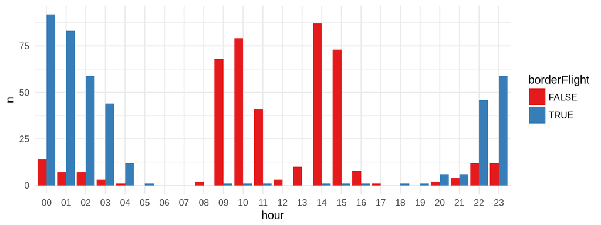

```r
hours <- bind_rows(border, domestic)

# replace NAs with 0
border[ is.na(border$n), ]$n <- 0
domestic[ is.na(domestic$n), ]$n <- 0
hours[ is.na(hours$n), ]$n <- 0

write.csv(hours, file = "output/hours.csv")

# clean up
rm(zeros, border, domestic)

# plot date bar chart
ggplot(hours, aes(x = hour, y = n )) +
  geom_bar( aes(fill = borderFlight),
            stat="identity",
            position="dodge") +
  theme_minimal() +
  scale_fill_brewer(palette = "Set1")
```

### 1.b. In welchen Wochen gibt es wie viele Einsätze?

In den folgenden Auswertungen wird lediglich der Startzeitpunkt eines Flugs betrachtet. Startet eine Drohne um 23:55 und fliegt sie bis 01:00 so wird sie trotzdem dem Vortag zugerechnet.

```r
weeks <- flights %>%
  group_by( drone, flight, borderFlight ) %>%
  summarise( start = min( date )) %>%
  arrange( start ) %>%
  group_by( week = strftime( start, format="%y-%V" ), drone, flight, borderFlight ) %>%
  tally() %>%
  select( -n )

weeks %<>%
  group_by( week, borderFlight ) %>%
  tally()

# fill up with zeros
zeros <- as.data.frame( list( week = format( seq( from = as.Date( head(weeks$week, n = 1 ), format = '%y-%V' ), to = as.Date( tail(weeks$week, n = 1 ), format = '%y-%V' ), 'weeks' ), format = '%y-%V' )))

# merge is a bit complicated because both borderFlight true and false have to filled up with zeros
border <- weeks %>% filter( borderFlight ) %>% right_join( zeros ) %>% mutate( borderFlight = ifelse( is.na( borderFlight ), TRUE, borderFlight ))
domestic <- weeks %>% filter( !borderFlight ) %>% right_join( zeros ) %>% mutate( borderFlight = ifelse( is.na( borderFlight ), FALSE, borderFlight ))
```

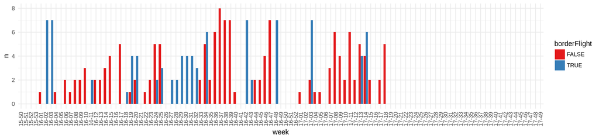

```r
weeks <- bind_rows(border, domestic)

# replace NAs with 0
weeks[ is.na(weeks$n), ]$n <- 0

# clean up
rm(zeros, border, domestic)

# plot date bar chart
ggplot(weeks, aes(x = week, y = n )) +
  geom_bar( aes(fill = borderFlight),
            stat="identity",
            position="dodge") +
  theme_minimal() +
  scale_fill_brewer(palette = "Set1") +
  theme(axis.text.x=element_text(angle = 90, vjust = 0.5, hjust=1))
```

### 1.c. In welchen Monaten?

```r
months <- flights %>%
  group_by( drone, flight, borderFlight ) %>%
  summarise( start = min(date)) %>%
  arrange( start ) %>%
  group_by( month = strftime( start, format="%y-%m" ), drone, flight, borderFlight ) %>%
  tally() %>%
  select( -n )

months %<>%
  group_by( month, borderFlight ) %>%
  tally()

# fill up with zeros
zeros <- as.data.frame( list( month = format( seq( from = as.Date( paste0( head( months$month, n = 1 ), "-01"), format = '%y-%m-%d' ), to = as.Date( paste0( tail( months$month, n = 1 ), "-01"), format = '%y-%m-%d' ), 'months' ), format = '%y-%m' )))

# merge is a bit complicated because both borderFlight true and false have to filled up with zeros
border <- months %>% filter( borderFlight ) %>% right_join( zeros ) %>% mutate( borderFlight = ifelse( is.na( borderFlight ), TRUE, borderFlight ))
domestic <- months %>% filter( !borderFlight ) %>% right_join( zeros ) %>% mutate( borderFlight = ifelse( is.na( borderFlight ), FALSE, borderFlight ))
```

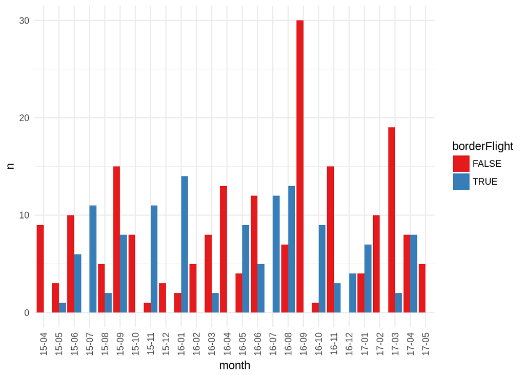

```r
months <- bind_rows(border, domestic)

# replace NAs with 0
months[ is.na(months$n), ]$n <- 0

# clean up
rm(zeros, border, domestic)

# plot date bar chart
ggplot(months, aes(x = month, y = n )) +
  geom_bar( aes(fill = borderFlight),
            stat="identity",
            position="dodge") +
  theme_minimal() +
  scale_fill_brewer(palette = "Set1") +
  theme(axis.text.x=element_text(angle = 90, vjust = 0.5, hjust=1))
```

### 1.d. An welchen Wochentagen gibt es wie viele Einsätze?

```r
weekdays <- flights %>%
  group_by( drone, flight, borderFlight ) %>%
  summarise( start = min(date)) %>%
  arrange( start ) %>%
  group_by( weekday = strftime( start, format="%u" ), drone, flight, borderFlight ) %>%
  tally() %>%
  select( -n )

weekdays %<>%
  group_by( weekday, borderFlight ) %>%
  tally()

# fill up with zeros
zeros <- as.data.frame(list(weekday = as.character(seq(1, 7))))

# merge is a bit complicated because both borderFlight true and false have to filled up with zeros
border <- weekdays %>% filter( borderFlight ) %>% right_join( zeros ) %>% mutate( borderFlight = ifelse( is.na( borderFlight ), TRUE, borderFlight ))
domestic <- weekdays %>% filter( !borderFlight ) %>% right_join( zeros ) %>% mutate( borderFlight = ifelse( is.na( borderFlight ), FALSE, borderFlight ))
```

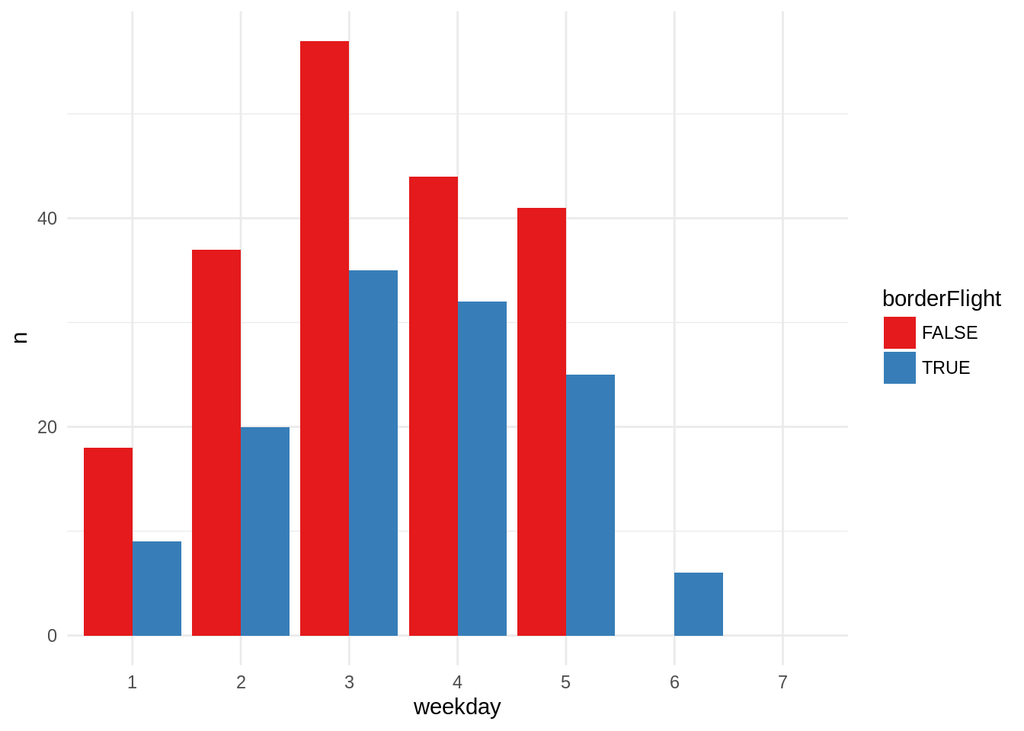

```r
weekdays <- bind_rows(border, domestic)

# replace NAs with 0
weekdays[ is.na(weekdays$n), ]$n <- 0

# export
write.csv(weekdays, file = "output/weekdays.csv")

# clean up
rm(zeros)

# plot date bar chart
ggplot(weekdays, aes(x = weekday, y = n )) +
  geom_bar( aes(fill = borderFlight),
            stat="identity",
            position="dodge") +
  theme_minimal() +
  scale_fill_brewer(palette = "Set1")
```

### 1.e. Wie oft wird an Wochenenden geflogen?

```r
print(paste("Am Samstag wurde", weekdays[weekdays$weekday == "6", ]$n, "Mal gestartet, am Sonntag", weekdays[weekdays$weekday == "7", ]$n, "Mal"))
```

```
## [1] "Am Samstag wurde 6 Mal gestartet, am Sonntag 0 Mal"
## [2] "Am Samstag wurde 0 Mal gestartet, am Sonntag 0 Mal"
```

### 1.f. Wie lange wird durchschnittlich geflogen?

```r
print(paste("Der Median der Flugdauer beträgt ca.", round(median(durations$duration)/60), "Minuten"))
```

```
## [1] "Der Median der Flugdauer beträgt ca. 87 Minuten"
```

```r
print(paste("Der Durchschnitt ca.", round(mean(durations$duration)/60), "Minuten"))
```

```
## [1] "Der Durchschnitt ca. 92 Minuten"
```

### 1.g. Was war der längste Einsatz?

```r
longest <- head(durations %>% arrange(desc(duration)), 1)

print(paste("Der längste Einsatz war Flug", longest$flight, "von der Drohne", longest$drone, "- er war", round(longest$duration/60), "Minuten"))
```

```
## [1] "Der längste Einsatz war Flug 190598993 von der Drohne D127 - er war 220 Minuten"
```

### 1.h. An welchen Tagen des Jahres?

```r
days <- flights %>%
  group_by( drone, flight ) %>%
  summarise( start = min(date)) %>%
  group_by( day = strftime( start, format = '%Y-%m-%d' ), drone, flight) %>%
  tally() %>%
  select( -n )

days %<>%
  group_by( day ) %>%
  tally()

# fill up with zeros
zeros <- as.data.frame( seq( from = min(flights$date), to = max(flights$date), 'days' ))

# rename column for merging
names(zeros)[1] <- 'day'

# add column for weekday
zeros$weekday <- strftime( zeros$day, format = '%u')
zeros$week <- strftime( zeros$day, format = '%V')

# convert to string for merging
zeros$day <- strftime( zeros$day, format = '%Y-%m-%d' )

# merge
days <- right_join( days, zeros )
```

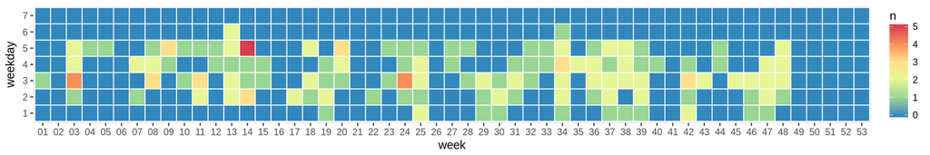

```r
# replace NAs with 0
days[ is.na(days$n), ]$n <- 0

# write to csv
write.csv(days %>% rename( count = n, date = day ) %>% select(date, count), file = "output/days.csv")

# clean up
rm(zeros)

# plot date bar chart
ggplot(data = days, aes(x = week, y = weekday, fill = n)) +
  geom_tile(color = "white", size = 0.4) +
  scale_fill_distiller(palette = "Spectral")
```

## 2. Regionale Muster

### 2.a. Wann ist der Stichtag, an dem der Trend von Ost-Grenze zu Süd-Grenze shiftet?

Sidenote: Am 18. März 2016 (1458255600), hatten sich die EU-Länder und die Türkei auf ein Abkommen geeinigt.

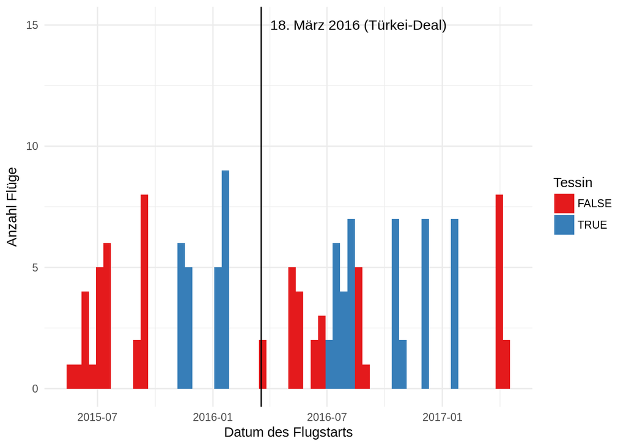

```r
meanBorderFlights <- borderFlights %>%
  group_by(drone, flight) %>%
  summarise(start = min(date), latMean = mean(as.numeric(lat)), longMean = mean(as.numeric(long))) %>%
  mutate(Tessin = latMean < 46.25) %>%
  ungroup()

ggplot(meanBorderFlights, aes(x = start, fill = Tessin)) +
  labs(x = "Datum des Flugstarts", y = "Anzahl Flüge") +
  geom_histogram(bins = 60) +
  theme_minimal() +
  scale_fill_brewer(palette = "Set1") +
  geom_vline(xintercept = 1458255600) +
  annotate("text", label = "18. März 2016 (Türkei-Deal)", x = as.POSIXct('2016-03-18'), y = 15, hjust = -0.05, size = 4)
```

```r
# output
print(paste(sum(meanBorderFlights$Tessin), "von", nrow(meanBorderFlights), "Flügen waren im Tessin"))
```

```
## [1] "67 von 127 Flügen waren im Tessin"
```

Bis Anfang Juli wird vor allem im Norden des Landes geflogen. Ab Juli vor allem im Süden. Im August allerdings auch nochmal im Norden. Zum Vergleich: Vor fast einem Jahr, am 18. März 2016, hatten sich die EU-Länder und die Türkei auf ein Abkommen geeinigt.

## 3. Technische Muster

### 3.a. Auf welcher Höhe (altitude) wird durchschnittlich geflogen? Was war die höchste gemessene Höhe?

```r
print(paste("Der Median der Flughöhe beträgt", median(borderFlights[!is.na(borderFlights$altitude), ]$altitude), "und der Durchschnitt", round(mean(borderFlights[!is.na(borderFlights$altitude), ]$altitude))))
```

```
## [1] "Der Median der Flughöhe beträgt 8500 und der Durchschnitt 8728"
```

```r
print("Angegeben bei der Flughöhe ist die Altitude - also Höhe über Meeresspiegel, allerdings in Fuss")
```

```
## [1] "Angegeben bei der Flughöhe ist die Altitude - also Höhe über Meeresspiegel, allerdings in Fuss"
```

```r
print(paste("Der höchste gemessene Punkt war auf", max(borderFlights$altitude), "was wie ein Messfehler wirkt"))
```

```
## [1] "Der höchste gemessene Punkt war auf 50175 was wie ein Messfehler wirkt"
```

### 3.b. Wie schnell (Speed) wird durchschnittlich geflogen? Was war die höchste gemessene Geschwindigkeit?

```r
print(paste("Der Median der Geschwindigkeit beträgt", round(median(borderFlights[borderFlights$speed > 0, ]$speed)), "und der Durchschnitt", round(mean(borderFlights[borderFlights$speed > 0, ]$speed))))
```

```
## [1] "Der Median der Geschwindigkeit beträgt 131 und der Durchschnitt 132"
```

```r
print(paste("Die höchste gemessene Geschwindigkeit war", round(max(borderFlights$speed)), "was damit zusammenhängt, dass alle Punkte mit einer Geschwindigkeit über 250 km/h weggefiltert werden, weil es sich zu einem grossen Teil um Messfehler/Ausreisser handelt"))
```

```
## [1] "Die höchste gemessene Geschwindigkeit war 250 was damit zusammenhängt, dass alle Punkte mit einer Geschwindigkeit über 250 km/h weggefiltert werden, weil es sich zu einem grossen Teil um Messfehler/Ausreisser handelt"
```

## 4. Allgemeine Facts

### 4.a. Welche Daten liegen vor?

```r
print( paste("Von", min(flights$date), "bis", max(flights$date), "sind", nrow(flights %>% distinct(flight)), "Flüge registriert"))
```

```
## [1] "Von 2015-04-16 14:39:13 bis 2017-05-05 15:49:00 sind 324 Flüge registriert"
```

```r
print( paste("Davon waren", nrow(borderFlightIDs), "Flüge grenznah - haben also einen Flugpunkt, der näher als 5km zur Schweizer Grenze liegt"))
```

```
## [1] "Davon waren 127 Flüge grenznah - haben also einen Flugpunkt, der näher als 5km zur Schweizer Grenze liegt"
```

### 4.b. Wie viele Minuten waren die Drohnen insgesamt in der Luft? Im Jahr 2016?

```r
totalHours <- round(sum(durations$duration)/3600)

print( paste("Insgesamt waren die Drohnen rund", totalHours, "Stunden in der Luft"))
```

```
## [1] "Insgesamt waren die Drohnen rund 570 Stunden in der Luft"
```

### 4.c. Total Kosten der Drohnen-Flüge für alle Daten, wenn die Stunde 7300 CHF kostet? Fürs Jahr 2016?

```r
print( paste("Bei einem Preis von CHF 7300 pro Stunde ergibt das Gesamtkosten in Höhe von CHF", format( totalHours*7300, big.mark = "'")))
```

```
## [1] "Bei einem Preis von CHF 7300 pro Stunde ergibt das Gesamtkosten in Höhe von CHF 4'161'000"
```

```r
print( paste("Das macht pro Flug im Schnitt CHF", format( totalHours*7300 / nrow(flights %>% distinct(flight)), big.mark = "'")))
```

```
## [1] "Das macht pro Flug im Schnitt CHF 12'842.59"
```

## 5. Flughöhe

### 5.a. Wo flogen die Drohnen wie hoch?

```r
# read in geoTIF of srtm90 data <http://srtm.csi.cgiar.org/SELECTION/inputCoord.asp>
srtm_38_03 <- raster('input/geodata/srtm_38_03/srtm_38_03.tif')
srtm_39_03 <- raster('input/geodata/srtm_39_03/srtm_39_03.tif')

# merge two squares together but in this case this is not necessary
# 3903 is only a small part of Graubünden where no data points are, so it can be left out
raster <- srtm_38_03 # otherwise we would write here: merge(srtm_38_03, srtm_39_03)

# clean up
rm(srtm_38_03, srtm_39_03)

# calculate ground level (meters above sea level M.ü.M. for each long/lat data point)
ground <- raster::extract(raster, spatialFlights)

# transform for merging
ground <- as.data.frame(c(ground))

# rename new column
names(ground)[1] <- 'groundlevel'

# bind together
flights %<>% bind_cols(ground)

# convert altitude from feet to meters
# according to wikipedia the ranger drone can only fly up to 4500 meters so we filter out mismeasurements > 5000 m
# filter out data points with meters above ground is smaller than zero
flights %<>% mutate(altitude = altitude * 0.3048) %>%
  mutate(aboveGround = altitude - groundlevel) %>%
  filter(aboveGround > 0, aboveGround < 5000)

# output
print(paste((nrow(spatialFlights) - nrow(flights)), "Datenpunkte wurden entfernt, weil sie eine unrealistische Flughöhe beinhalten"))
```

```
## [1] "300 Datenpunkte wurden entfernt, weil sie eine unrealistische Flughöhe beinhalten"
```

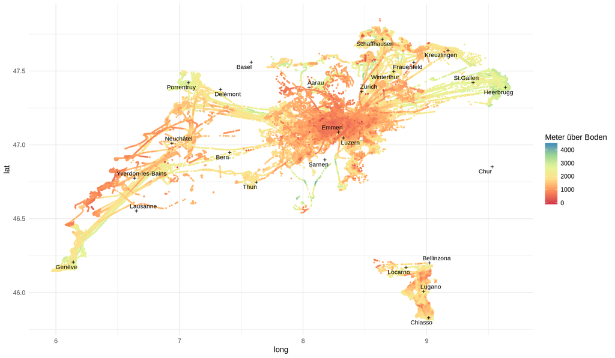

```r
# read in list of 20 swiss cities to plot
cities <- read.csv('input/geodata/staedte.csv', stringsAsFactors = FALSE)

# arrange that low flight levels (dark red) are visible
ggplot(flights %>% arrange(desc(aboveGround)), aes(x = long, y = lat)) +
  geom_point(aes(col = aboveGround), size = 0.5) +
  theme_minimal() +
  scale_colour_distiller(palette = "Spectral", direction = 1, limits = c(0, 4500)) +
  labs(col = "Meter über Boden") +
  geom_point(data = cities, shape = 3, size = 1) +
  geom_text_repel(data = cities, label = cities$Name, size = 3)
```

### 5.a Wie hoch flogen die Drohnen durchschnittlich im Inland und an den Grenzregionen?

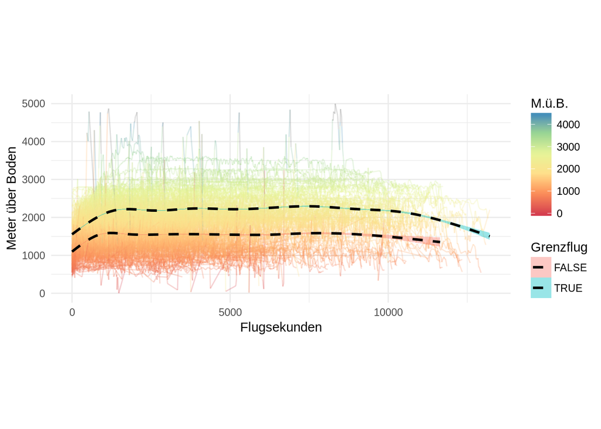

```r
# calculat new column seconds by substracting the start Timestamp from each data point
ggplot(flights %>% group_by(flight) %>% mutate(seconds = Timestamp - min(Timestamp)), aes(x = seconds, y = aboveGround, col = aboveGround, group = flight)) +
  geom_line(alpha = 0.25) +
  theme_minimal() +
  scale_colour_distiller(palette = "Spectral", direction = 1, limits = c(0, 4500)) +
  geom_smooth(aes(group = borderFlight, fill = borderFlight), show.legend = TRUE, linetype = "dashed", col = "black") +
  labs(y = "Meter über Boden", x = "Flugsekunden", col = "M.ü.B.", fill = "Grenzflug") +
  coord_fixed(ratio = 1.2)
```